# Part II - Prosper Loan Dataset Exploration: Employment status of loan borrowers and their loan completion status

## by Akinwale Akinjiola

## Dataset Overview

The Prosper Loan Dataset is financial dataset that consists of information on 113,937 loan transactions, with 81 associated variables/characteristics on each loan including amount, interest rate, current status, borrower income, and many others.

## Distribution of the Employment Status in the Prosper Loan Dataset?

More than 80% of the borrowers in the dataset are either `Employed` or `Full-time` workers and ~6.7% of the status is not available in the data

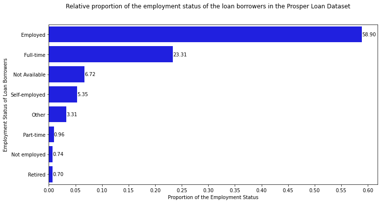

## Distribution of the Employment Status and Loan Status

A large proportion of the loans with 'Current' status are listed by borrowers who were Employed and followed by those Self-Employed. While the 'Completed' loans are listed by Employed and Full-time.

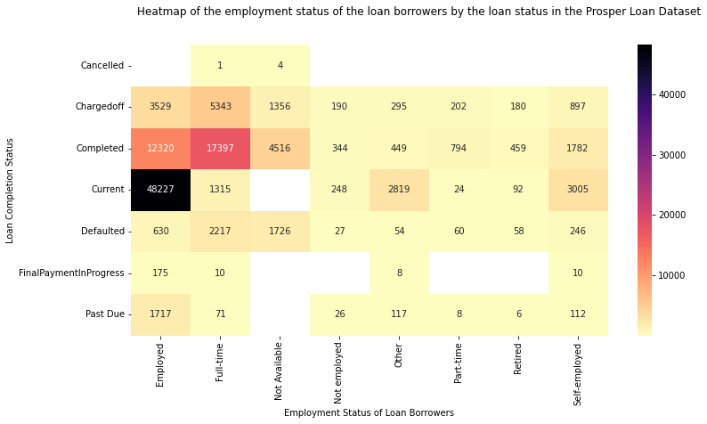

## Employment Status and Loan Status on a Yearly basis

Over the 10 year period of the Prosper loan, the listing of the loans showed:

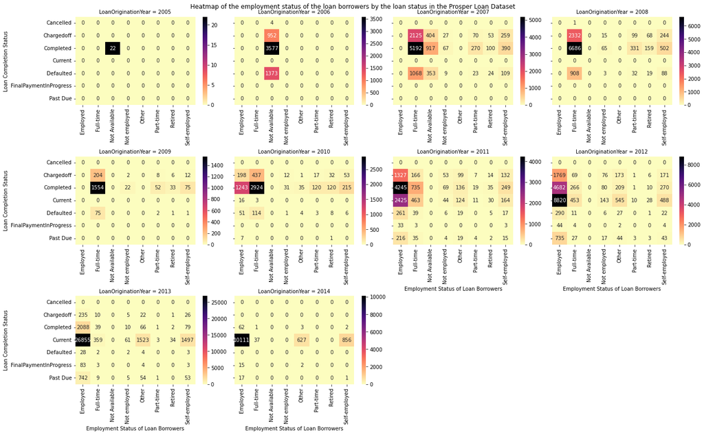

#### In Summary:

- The Prosper loans were given for durations of 12-*short*, 36-*medium* and 60-*long* months, with majority of the loans of 36 months duration listed from 2005 and 2014.
- More than 80% of the borrowers in the dataset were either Employed *(58.9%)* or Full-time *(23.3%)* workers and *6.7%* of the employment status of the loan borrowers was not available in the data.
- Approximately 82% of the loans listed were either 'Current' or 'Completed', and less than *1%* of the loans were in listed in the 'FinalPaymentInProgress' state.
- The borrowers of the loan covered a very large area of occupation from Professionals to Skilled Workers to Administrative Assistants, as well as Students
- The yearly listing of the loans reflect in the number of loans:
  - a decline from 2008 to 2009 - where are no loans listed with the 'Current', 'FinalPaymentInProgress' and 'PastDue' status;
  - a rise from 2010 till 2013 - where there was a steady rise in the number of listed loans from 2010 and may be accounted for by the increase in the loans listed as 'Current' as well as the Employed;
  - and a sharp drop from 2013 to 2014 - where there was only data for the first quarter of 2014.